# occurrence_visualization

## GBIF数据字段解释

### 标识字段

gbifID：GBIF系统内部的唯一标识符

datasetKey：数据集的唯一标识符

occurrenceID：在源数据集中的唯一标识符

### 分类学字段

kingdom → species：从界到种的分类层级

infraspecificEpithet：种下单位（变种、亚种等）的加词

taxonRank：分类等级（如：SPECIES, SUBSPECIES, VARIETY）

scientificName：接受/标准的科学名称

verbatimScientificName：原始记录中的科学名称

verbatimScientificNameAuthorship：原始记录的作者名

taxonKey：GBIF分类学主键

speciesKey：物种级分类学主键

### 地点信息字段

countryCode：国家代码（ISO 2字母代码，如SE=瑞典）

locality：具体地点描述

stateProvince：省/州/地区

decimalLatitude：十进制纬度

decimalLongitude：十进制度经度

coordinateUncertaintyInMeters：坐标不确定度（米）

coordinatePrecision：坐标精度

elevation → depthAccuracy：高程和深度相关精度信息

### 采集信息字段

occurrenceStatus：存在状态（PRESENT/ABSENT）

individualCount：个体数量

eventDate：采集/观察日期

day/month/year：日期分解

recordedBy：记录者

identifiedBy：鉴定者

dateIdentified：鉴定日期

basisOfRecord：记录基础类型（如PRESERVED_SPECIMEN=标本）

### 机构与权限字段

publishingOrgKey：发布机构标识

institutionCode：机构代码（如PE=北京植物标本馆）

collectionCode：馆藏代码

catalogNumber：标本馆编号

recordNumber：野外采集编号

typeStatus：模式状态

license：使用许可协议（如CC_BY_NC_4_0=知识共享署名-非商业性使用4.0）

rightsHolder：版权持有者

### 元数据字段

lastInterpreted：GBIF最后一次解释该记录的时间

mediaType：媒体类型

issue：数据质量问题标记（重要！）

### 问题字段（issue）详解

这是质量评估标记，指示可能存在的数据问题：

RECORDED_DATE_MISMATCH：记录日期不匹配

COUNTRY_COORDINATE_MISMATCH：国家与坐标不匹配

COUNTRY_INVALID：国家信息无效

GEODETIC_DATUM_ASSUMED_WGS84：假定使用WGS84坐标系

CONTINENT_DERIVED_FROM_COORDINATES：从坐标推导大陆

INSTITUTION_MATCH_FUZZY：机构匹配模糊

COLLECTION_MATCH_NONE：无匹配的馆藏

### 脚本新增字段

species_std：脚本生成的标准化物种名（从指定优先级列获取）

## 导入库和设置

```python
# 导入必要的库
import pandas as pd
import numpy as np
import matplotlib.pyplot as plt
import seaborn as sns
import plotly.express as px
import geopandas as gpd
from shapely.geometry import Point
import warnings
warnings.filterwarnings('ignore')

# 设置中文显示和绘图样式
plt.rcParams['font.sans-serif'] = ['SimHei', 'DejaVu Sans']
plt.rcParams['axes.unicode_minus'] = False
sns.set_style("whitegrid")
sns.set_palette("husl")

# 显示所有列
pd.set_option('display.max_columns', None)
pd.set_option('display.max_rows', 100)
```

## 加载数据

```python
# 加载数据
file_path = "occurrence_clean.csv"

df = pd.read_csv(file_path, encoding='utf-8')
print(f"成功加载数据: {len(df)} 行, {len(df.columns)} 列")

# 显示前几行
print("\n数据前5行:")
display(df.head())

# 数据基本信息
print("\n数据基本信息:")
print(f"数据集形状: {df.shape}")
print("\n列名:")
print(df.columns.tolist())
```

```
成功加载数据: 195992 行, 51 列

数据前5行:
```

|  | gbifID | datasetKey | occurrenceID | kingdom | phylum | class | order | family | genus | species | infraspecificEpithet | taxonRank | scientificName | verbatimScientificName | verbatimScientificNameAuthorship | countryCode | locality | stateProvince | occurrenceStatus | individualCount | publishingOrgKey | decimalLatitude | decimalLongitude | coordinateUncertaintyInMeters | coordinatePrecision | elevation | elevationAccuracy | depth | depthAccuracy | … |
| --- | --- | --- | --- | --- | --- | --- | --- | --- | --- | --- | --- | --- | --- | --- | --- | --- | --- | --- | --- | --- | --- | --- | --- | --- | --- | --- | --- | --- | --- | --- |
| 0 | 4042725131 | 780977d6-1cdb-4804-904f-9303cce8b4a1 | 15048036 | Plantae | Tracheophyta | Magnoliopsida | Ranunculales | Ranunculaceae | Aconitum | Aconitum lycoctonum | lycoctonum | SUBSPECIES | Aconitum lycoctonum subsp. lycoctonum | Aconitum lycoctonum subsp. lycoctonum | NaN | SE | Kt.Obwalden | NaN | PRESENT | NaN | a2fa5b68-3ebf-4845-abc5-f456d251386f | 46.83000 | 8.29000 | NaN | NaN | NaN | NaN | NaN | NaN | … |
| 1 | 4042785757 | 780977d6-1cdb-4804-904f-9303cce8b4a1 | 16529909 | Plantae | Tracheophyta | Magnoliopsida | Rosales | Ulmaceae | Ulmus | Ulmus laevis | NaN | SPECIES | Ulmus laevis Pall. | Ulmus laevis | NaN | SE | Fennicae | NaN | PRESENT | NaN | a2fa5b68-3ebf-4845-abc5-f456d251386f | 61.28000 | 24.08000 | NaN | NaN | NaN | NaN | NaN | NaN | … |
| 2 | 4042915575 | 780977d6-1cdb-4804-904f-9303cce8b4a1 | 16539693 | Plantae | Tracheophyta | Magnoliopsida | Rosales | Rosaceae | Potentilla | Potentilla neglecta | incanescens | VARIETY | Potentilla argentea var. incanescens (Opiz) Focke | Potentilla argentea var. incanescens | NaN | SE | Fennicae | NaN | PRESENT | NaN | a2fa5b68-3ebf-4845-abc5-f456d251386f | 61.33000 | 24.27000 | NaN | NaN | NaN | NaN | NaN | NaN | … |
| 3 | 4042915441 | 780977d6-1cdb-4804-904f-9303cce8b4a1 | 16529908 | Plantae | Tracheophyta | Magnoliopsida | Ranunculales | Ranunculaceae | Ranunculus | Ranunculus laeticolor | NaN | SPECIES | Ranunculus laeticolor (Markl.) Ericsson | Ranunculus laeticolor | NaN | SE | Fennicae | NaN | PRESENT | NaN | a2fa5b68-3ebf-4845-abc5-f456d251386f | 61.33000 | 24.27000 | NaN | NaN | NaN | NaN | NaN | NaN | … |
| 4 | 4065321199 | 38b4c89f-584c-41bb-bd8f-cd1def33e92f | urn:lsid:artportalen.se:sighting:107521197 | Plantae | Tracheophyta | Magnoliopsida | Asterales | Asteraceae | Antennaria | Antennaria dioica | NaN | SPECIES | Antennaria dioica (L.) Gaertn. | Antennaria dioica | (L.) Gaertn. | SE | Guijaurtjårros S-sluttning, Pi lm | Pite lappmark | PRESENT | NaN | b8323864-602a-4a7d-9127-bb903054e97d | 66.58146 | 16.02233 | 100.0 | NaN | NaN | NaN | NaN | NaN | … |

```
数据基本信息:
数据集形状: (195992, 51)

列名:
['gbifID', 'datasetKey', 'occurrenceID', 'kingdom', 'phylum', 'class', 'order', 'family', 'genus', 'species', 'infraspecificEpithet', 'taxonRank', 'scientificName', 'verbatimScientificName', 'verbatimScientificNameAuthorship', 'countryCode', 'locality', 'stateProvince', 'occurrenceStatus', 'individu…
```

## EDA数据探索

```python
# 数据概览
print("=== 数据概览 ===")
print(f"总记录数: {len(df):,}")
print(f"物种数: {df['species_std'].nunique() if 'species_std' in df.columns else 'N/A'}")
print(f"科数: {df['family'].nunique() if 'family' in df.columns else 'N/A'}")
print(f"属数: {df['genus'].nunique() if 'genus' in df.columns else 'N/A'}")

# 检查坐标数据
if 'decimalLatitude' in df.columns and 'decimalLongitude' in df.columns:
    print(f"\n=== 坐标信息 ===")
    print(f"纬度范围: [{df['decimalLatitude'].min():.2f}, {df['decimalLatitude'].max():.2f}]")
    print(f"经度范围: [{df['decimalLongitude'].min():.2f}, {df['decimalLongitude'].max():.2f}]")
    print(f"有坐标的记录数: {df[['decimalLatitude', 'decimalLongitude']].dropna().shape[0]:,}")

# 检查时间信息
if 'year' in df.columns:
    print(f"\n=== 时间信息 ===")
    print(f"时间范围: [{df['year'].min()} - {df['year'].max()}]")
    print(f"有年份的记录数: {df['year'].dropna().shape[0]:,}")
```

```
=== 数据概览 ===
总记录数: 195,992
物种数: 6081
科数: 127
属数: 835

=== 坐标信息 ===
纬度范围: [-3.26, 75.42]
经度范围: [-78.18, 99.69]
有坐标的记录数: 195,992

=== 时间信息 ===
时间范围: [2000 - 2024]
有年份的记录数: 195,992
```

```
=== 缺失值检查 ===
```

|  | 缺失数量 | 缺失百分比 |
| --- | --- | --- |
| depthAccuracy | 195992 | 100.000000 |
| depth | 195992 | 100.000000 |
| establishmentMeans | 195989 | 99.998469 |
| typeStatus | 195905 | 99.955610 |
| elevationAccuracy | 195865 | 99.935201 |
| coordinatePrecision | 195629 | 99.814788 |
| elevation | 195083 | 99.536206 |
| dateIdentified | 194606 | 99.292828 |
| recordNumber | 189578 | 96.727417 |
| mediaType | 189542 | 96.709049 |
| infraspecificEpithet | 171478 | 87.492347 |
| identifiedBy | 168365 | 85.904016 |
| individualCount | 136176 | 69.480387 |
| verbatimScientificNameAuthorship | 85799 | 43.776787 |
| rightsHolder | 80449 | 41.047084 |
| coordinateUncertaintyInMeters | 55777 | 28.458815 |
| stateProvince | 22613 | 11.537716 |
| locality | 21098 | 10.764725 |
| species | 11230 | 5.729826 |
| speciesKey | 11230 | 5.729826 |
| day | 3496 | 1.783746 |
| month | 511 | 0.260725 |
| genus | 217 | 0.110719 |
| institutionCode | 215 | 0.109698 |
| collectionCode | 164 | 0.083677 |
| catalogNumber | 137 | 0.069901 |
| recordedBy | 57 | 0.029083 |
| occurrenceID | 48 | 0.024491 |
| issue | 22 | 0.011225 |

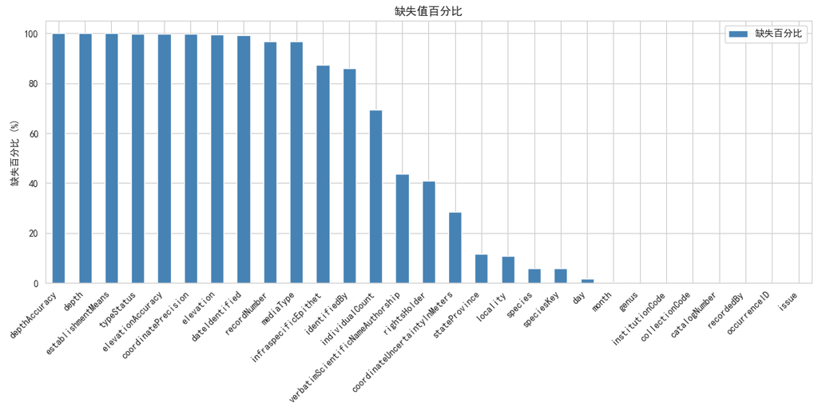

```python
# 缺失值检查
print("=== 缺失值检查 ===")
missing_data = df.isnull().sum().sort_values(ascending=False)
missing_percent = (df.isnull().sum() / len(df) * 100).sort_values(ascending=False)
missing_df = pd.DataFrame({
    '缺失数量': missing_data,
    '缺失百分比': missing_percent
})
missing_df = missing_df[missing_df['缺失数量'] > 0]

if len(missing_df) > 0:
    display(missing_df)

    # 可视化缺失值
    plt.figure(figsize=(12, 6))
    missing_df.plot(kind='bar', y='缺失百分比', ax=plt.gca(), color='steelblue')
    plt.title('缺失值百分比')
    plt.ylabel('缺失百分比 (%)')
    plt.xticks(rotation=45, ha='right')
    plt.tight_layout()

    # 确保中文字体能正确显示
    plt.rcParams['font.sans-serif'] = ['SimHei', 'DejaVu Sans']
    plt.rcParams['axes.unicode_minus'] = False

    plt.show()
else:
    print("没有缺失值！")
```

```
=== 物种多样性分析 ===

=== KINGDOM 级别分析 ===
不同的kingdom数量: 1
```

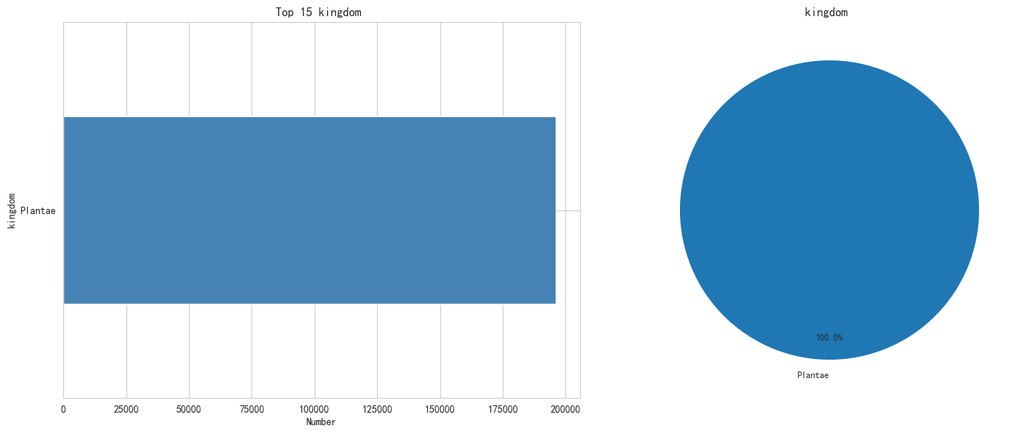

```
=== PHYLUM 级别分析 ===
不同的phylum数量: 1
```

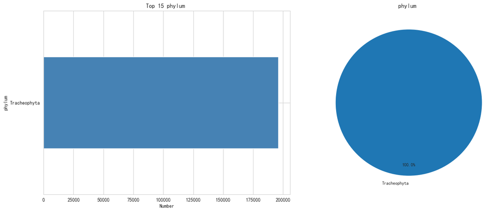

```
=== CLASS 级别分析 ===
不同的class数量: 1
```

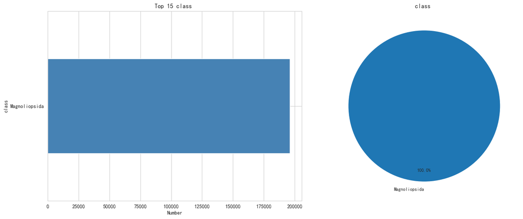

```
=== ORDER 级别分析 ===
不同的order数量: 37
```

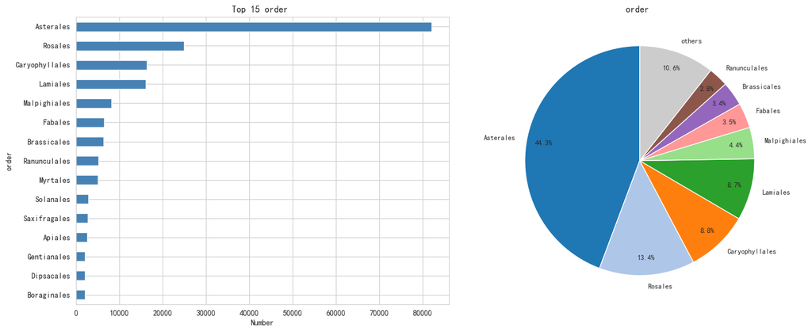

```
=== FAMILY 级别分析 ===
不同的family数量: 127
```

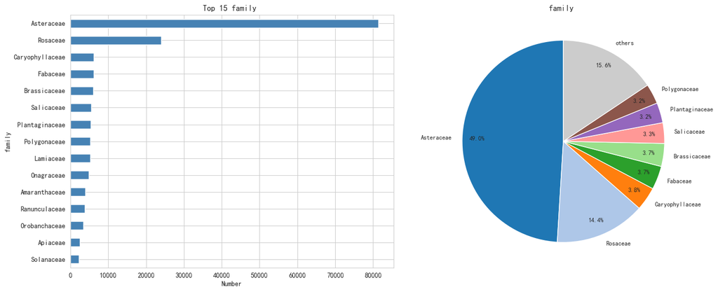

```
=== GENUS 级别分析 ===
不同的genus数量: 835
```

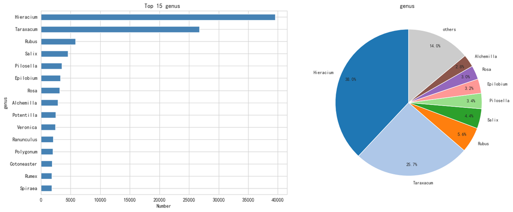

```
=== SPECIES_STD 级别分析 ===
不同的species_std数量: 6081
```

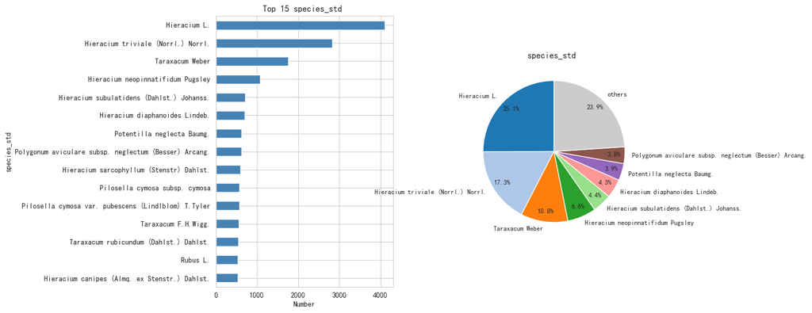

```python
# 物种丰富度统计
print("=== 物种多样性分析 ===")

# 分类层级统计函数
def plot_taxonomic_composition(df, level='family', top_n=15):
    """绘制分类层级组成图"""
    if level not in df.columns:
        print(f"数据中没有'{level}'字段")
        return

    counts = df[level].value_counts().head(top_n)

    # 创建子图
    fig, (ax1, ax2) = plt.subplots(1, 2, figsize=(15, 6))

    n_colors = len(counts)
    colors = plt.cm.tab20(np.linspace(0, 1, n_colors))
    counts.sort_values().plot(kind='barh', ax=ax1, color=colors)
    # 条形图
    counts.sort_values().plot(kind='barh', ax=ax1, color='steelblue')
    ax1.set_title(f'Top {top_n} {level} ')
    ax1.set_xlabel('Number')

    # 饼图
    if len(counts) > 0:
        # 只显示前8个，其他归为"其他"
        if len(counts) > 8:
            top_8 = counts.head(8)
            other = counts[8:].sum()
            pie_data = pd.concat([top_8, pd.Series([other], index=['others'])])
            pie_colors = list(colors[:8]) + ['#CCCCCC']
        else:
            pie_data = counts
            pie_colors = colors

        ax2.pie(pie_data, labels=pie_data.index, colors=pie_colors, autopct='%1.1f%%',
                        startangle=90, textprops={'fontsize': 9}, pctdistance=0.85)
        ax2.set_title(f'{level} ')

    plt.tight_layout()
    plt.show()

    return counts

# 按不同分类级别分析
for level in ['kingdom', 'phylum', 'class', 'order', 'family', 'genus', 'species_std']:
    if level in df.columns:
        print(f"\n=== {level.upper()} 级别分析 ===")
        print(f"不同的{level}数量: {df[level].nunique()}")
        top_counts = plot_taxonomic_composition(df, level, 15)
```

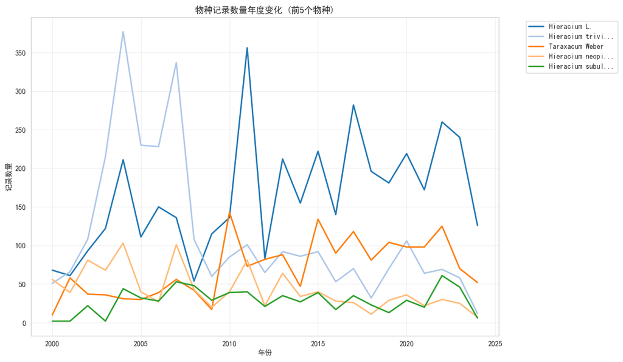

```python
import matplotlib.pyplot as plt
import pandas as pd
import numpy as np

# 清理年份数据
df_clean = df.copy()
df_clean['year'] = pd.to_numeric(df_clean['year'], errors='coerce')
df_clean = df_clean.dropna(subset=['year'])
df_clean['year'] = df_clean['year'].astype(int)

# 获取前10个物种
top_n = 5
species_counts = df_clean['species_std'].value_counts()
top_species = species_counts.head(top_n).index.tolist()

cmap = plt.cm.tab20
colors = [cmap(i / 20) for i in range(top_n)]  # 直接获取RGBA

# 创建图形
fig, ax = plt.subplots(figsize=(12, 7))

# 为每个物种绘制折线
for i, species in enumerate(top_species):
    species_data = df_clean[df_clean['species_std'] == species]
    yearly_counts = species_data['year'].value_counts().sort_index()

    ax.plot(yearly_counts.index, yearly_counts.values,
            color=colors[i % len(colors)],  # 循环使用颜色
            linewidth=2,
            label=species[:15] + ('...' if len(species) > 15 else ''))

# 设置图形
ax.set_xlabel('年份')
ax.set_ylabel('记录数量')
ax.set_title(f'物种记录数量年度变化 (前{top_n}个物种)')
ax.legend(bbox_to_anchor=(1.05, 1), loc='upper left')
ax.grid(True, alpha=0.3)

plt.tight_layout()
plt.show()
```

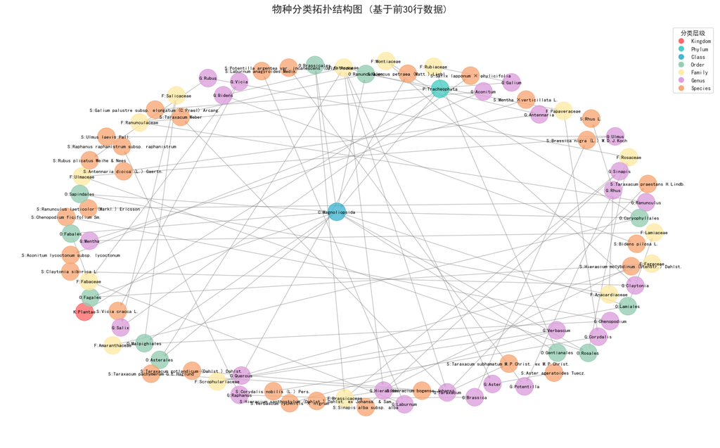

```python
import networkx as nx
import matplotlib.pyplot as plt
import pandas as pd
from collections import defaultdict

# 获取前100行数据
df_sample = df.head(30).copy()

# 创建分类层级拓扑（物种分类关系）
def create_taxonomic_topology(df_sample):
    """创建分类层级拓扑图"""
    G = nx.DiGraph()  # 有向图

    # 添加节点
    categories = defaultdict(list)

    for idx, row in df_sample.iterrows():
        # 定义分类层级
        taxon_levels = ['kingdom', 'phylum', 'class', 'order', 'family', 'genus', 'species_std']

        # 添加每个层级的节点
        for i, level in enumerate(taxon_levels):
            if pd.notna(row[level]) and row[level] != '':
                node_name = f"{level[0].upper()}:{row[level]}"
                G.add_node(node_name, level=level, value=row[level])

                # 添加上一层的边
                if i > 0:
                    prev_level = taxon_levels[i-1]
                    if pd.notna(row[prev_level]) and row[prev_level] != '':
                        prev_node = f"{prev_level[0].upper()}:{row[prev_level]}"
                        G.add_edge(prev_node, node_name)

                categories[level].append(row[level])

    return G, categories

# 创建拓扑图
G, categories = create_taxonomic_topology(df_sample)

# 绘制拓扑图
plt.figure(figsize=(16, 10))

# 使用层次布局
pos = nx.spring_layout(G, k=2, iterations=50)

# 按层级分配颜色
node_colors = []
for node in G.nodes():
    level = G.nodes[node].get('level', 'unknown')
    if 'kingdom' in level.lower():
        node_colors.append('#FF6B6B')  # 红色
    elif 'phylum' in level.lower():
        node_colors.append('#4ECDC4')  # 青色
    elif 'class' in level.lower():
        node_colors.append('#45B7D1')  # 蓝色
    elif 'order' in level.lower():
        node_colors.append('#96CEB4')  # 绿色
    elif 'family' in level.lower():
        node_colors.append('#FFEAA7')  # 黄色
    elif 'genus' in level.lower():
        node_colors.append('#DDA0DD')  # 紫色
    else:
        node_colors.append('#F8A978')  # 橙色

# 绘制节点和边
nx.draw_networkx_nodes(G, pos, node_color=node_colors, node_size=800, alpha=0.8)
nx.draw_networkx_edges(G, pos, edge_color='gray', alpha=0.5, arrows=True, arrowstyle='-|>', arrowsize=10)
nx.draw_networkx_labels(G, pos, font_size=8, font_family='sans-serif')

plt.title(f'物种分类拓扑结构图 (基于前{len(df_sample)}行数据)', fontsize=16, fontweight='bold', pad=20)
plt.axis('off')

# 添加图例
legend_elements = [
    plt.Line2D([0], [0], marker='o', color='w', markerfacecolor='#FF6B6B', markersize=10, label='Kingdom'),
    plt.Line2D([0], [0], marker='o', color='w', markerfacecolor='#4ECDC4', markersize=10, label='Phylum'),
    plt.Line2D([0], [0], marker='o', color='w', markerfacecolor='#45B7D1', markersize=10, label='Class'),
    plt.Line2D([0], [0], marker='o', color='w', markerfacecolor='#96CEB4', markersize=10, label='Order'),
    plt.Line2D([0], [0], marker='o', color='w', markerfacecolor='#FFEAA7', markersize=10, label='Family'),
    plt.Line2D([0], [0], marker='o', color='w', markerfacecolor='#DDA0DD', markersize=10, label='Genus'),
    plt.Line2D([0], [0], marker='o', color='w', markerfacecolor='#F8A978', markersize=10, label='Species')
]
plt.legend(handles=legend_elements, loc='upper right', fontsize=9, title='分类层级')

plt.tight_layout()
plt.show()
```

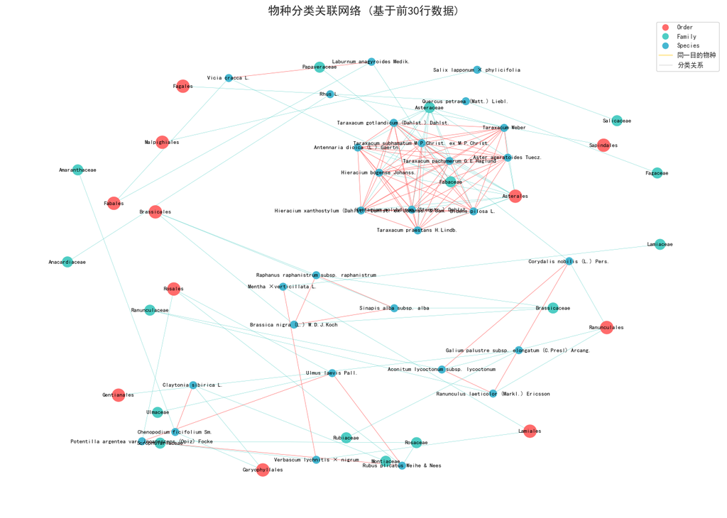

```python
# 物种关联网络（基于相同分类）
plt.figure(figsize=(14, 10))

# 创建关联图
G_assoc = nx.Graph()

# 统计每个分类的物种
from collections import defaultdict
order_species = defaultdict(set)
family_species = defaultdict(set)

for idx, row in df_sample.iterrows():
    species = row.get('species_std')
    order = row.get('order')
    family = row.get('family')

    if pd.notna(species) and species != '':
        G_assoc.add_node(species, type='species')

        if pd.notna(order) and order != '':
            order_species[order].add(species)
            G_assoc.add_node(order, type='order')
            G_assoc.add_edge(order, species)

        if pd.notna(family) and family != '':
            family_species[family].add(species)
            G_assoc.add_node(family, type='family')
            G_assoc.add_edge(family, species)

# 为同一目的物种添加边
for order, species_set in order_species.items():
    species_list = list(species_set)
    for i in range(len(species_list)):
        for j in range(i+1, len(species_list)):
            G_assoc.add_edge(species_list[i], species_list[j], type='same_order')

# 绘制
pos = nx.spring_layout(G_assoc, k=1, iterations=50)

# 按节点类型着色
node_colors = []
node_sizes = []
for node in G_assoc.nodes():
    node_type = G_assoc.nodes[node].get('type', 'species')
    if node_type == 'order':
        node_colors.append('#FF6B6B')
        node_sizes.append(300)
    elif node_type == 'family':
        node_colors.append('#4ECDC4')
        node_sizes.append(200)
    else:
        node_colors.append('#45B7D1')
        node_sizes.append(100)

# 按边类型设置样式
edge_colors = []
edge_widths = []
for u, v, data in G_assoc.edges(data=True):
    if data.get('type') == 'same_order':
        edge_colors.append('#FF6B6B')
        edge_widths.append(0.5)
    else:
        edge_colors.append('#4ECDC4')
        edge_widths.append(0.3)

nx.draw_networkx_nodes(G_assoc, pos, node_color=node_colors, node_size=node_sizes, alpha=1)
nx.draw_networkx_edges(G_assoc, pos, edge_color=edge_colors, width=edge_widths, alpha=1)
nx.draw_networkx_labels(G_assoc, pos, font_size=8, font_family='sans-serif')

plt.title(f'物种分类关联网络 (基于前{len(df_sample)}行数据)', fontsize=16, fontweight='bold')
plt.axis('off')

# 添加图例
legend_elements = [
    plt.Line2D([0], [0], marker='o', color='w', markerfacecolor='#FF6B6B', markersize=10, label='Order'),
    plt.Line2D([0], [0], marker='o', color='w', markerfacecolor='#4ECDC4', markersize=10, label='Family'),
    plt.Line2D([0], [0], marker='o', color='w', markerfacecolor='#45B7D1', markersize=10, label='Species'),
    plt.Line2D([0], [0], color='#FFEAA7', linewidth=2, label='同一目的物种'),
    plt.Line2D([0], [0], color='#DDDDDD', linewidth=1, label='分类关系')
]
plt.legend(handles=legend_elements, loc='upper right', fontsize=9)

plt.tight_layout()
plt.show()
```

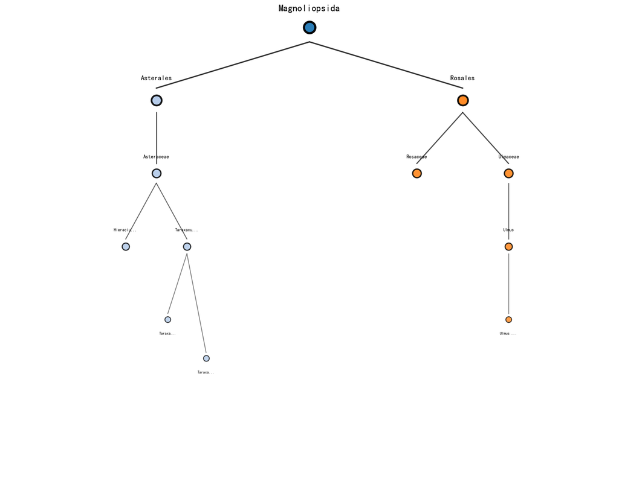

```python
def plot_full_taxonomic_tree_compact(df_sample):
    """紧凑版的五层分类树形图"""

    # 获取唯一的class
    unique_classes = df_sample['class'].dropna().unique()
    if len(unique_classes) == 0:
        print("没有找到class数据")
        return

    class_name = unique_classes[0]
    class_df = df_sample[df_sample['class'] == class_name]

    # 创建图形 - 背景改为白色
    fig, ax = plt.subplots(figsize=(20, 16))
    fig.patch.set_facecolor('white')  # 白色背景
    ax.set_facecolor('white')  # 白色背景

    # 使用tab20颜色
    cmap = plt.cm.tab20
    colors = [cmap(i/20) for i in range(20)]

    # 1. CLASS节点（最顶层）
    class_x, class_y = 0.5, 0.95
    class_size = 700

    # 节点边框改为黑色
    ax.scatter([class_x], [class_y], s=class_size,
              color=colors[0], alpha=0.95,
              edgecolors='black', linewidth=5, zorder=50)  # 白色改为黑色

    # 文字颜色改为黑色
    ax.text(class_x, 0.98, f"{class_name[:20]}{'...' if len(class_name) > 20 else ''}",
            ha='center', va='bottom', fontsize=22, fontweight='bold',
            color='black', zorder=51)  # 白色改为黑色

    # 2. ORDER节点（第二层）
    orders = class_df['order'].value_counts().head(2).index.tolist()

    if len(orders) == 1:
        order_x_positions = [0.5]
    else:
        order_x_positions = np.linspace(0.3, 0.7, len(orders))

    for i, order in enumerate(orders):
        order_x = order_x_positions[i]
        order_y = 0.8
        order_size = 550
        order_color = colors[i+1]

        # ORDER节点
        ax.scatter([order_x], [order_y], s=order_size,
                  color=order_color, alpha=0.9,
                  edgecolors='black', linewidth=4, zorder=40)  # 白色改为黑色

        ax.text(order_x, 0.84, f"{order[:12]}{'...' if len(order) > 12 else ''}",
                ha='center', va='bottom', fontsize=16, fontweight='bold',
                color='black', zorder=41)  # 白色改为黑色

        # 连接线改为黑色
        ax.plot([class_x, order_x], [class_y - 0.03, order_y + 0.025],
               'black', alpha=0.8, linewidth=3, zorder=30)  # 白色改为黑色，提高透明度

        # 3. FAMILY节点（第三层）
        order_df = class_df[class_df['order'] == order]
        families = order_df['family'].value_counts().head(2).index.tolist()

        for j, family in enumerate(families):
            if len(families) == 1:
                fam_x = order_x
            else:
                spacing = 0.12
                fam_x = order_x - (spacing/2) + j * spacing

            family_y = 0.65
            family_size = 400

            # FAMILY节点
            ax.scatter([fam_x], [family_y], s=family_size,
                      color=order_color, alpha=0.85,
                      edgecolors='black', linewidth=3, zorder=35)  # 白色改为黑色

            ax.text(fam_x, 0.68, f"{family[:10]}{'...' if len(family) > 10 else ''}",
                   ha='center', va='bottom', fontsize=12, fontweight='bold',
                   color='black', zorder=36)  # 白色改为黑色

            # 连接线改为黑色
            ax.plot([order_x, fam_x], [order_y - 0.025, family_y + 0.02],
                   'black', alpha=0.7, linewidth=2.5, zorder=25)  # 白色改为黑色，提高透明度

        # 4. GENUS节点（第四层）
        family_df = order_df[order_df['family'] == family]
        genera = family_df['genus'].value_counts().head(2).index.tolist()

        for k, genus in enumerate(genera):
            if len(genera) == 1:
                gen_x = fam_x
            else:
                spacing = 0.08
                gen_x = fam_x - (spacing/2) + k * spacing

            genus_y = 0.5
            genus_size = 280

            # GENUS节点
            ax.scatter([gen_x], [genus_y], s=genus_size,
                      color=order_color, alpha=0.8,
                      edgecolors='black', linewidth=2.5, zorder=30)  # 白色改为黑色

            ax.text(gen_x, 0.53, f"{genus[:8]}{'...' if len(genus) > 8 else ''}",
                   ha='center', va='bottom', fontsize=10,
                   color='black', zorder=31)  # 白色改为黑色

            # 连接线改为黑色
            ax.plot([fam_x, gen_x], [family_y - 0.02, genus_y + 0.015],
                   'black', alpha=0.6, linewidth=2, zorder=20)  # 白色改为黑色，提高透明度

        # 5. SPECIES节点（第五层）
        genus_df = family_df[family_df['genus'] == genus]
        species_list = genus_df['species_std'].value_counts().head(2).index.tolist()

        for m, species in enumerate(species_list):
            if len(species_list) == 1:
                sp_x = gen_x
            else:
                spacing = 0.05
                sp_x = gen_x - (spacing/2) + m * spacing

            species_y = 0.35 - m * 0.08
            species_size = 180

            # SPECIES节点
            ax.scatter([sp_x], [species_y], s=species_size,
                      color=order_color, alpha=0.75,
                      edgecolors='black', linewidth=2, zorder=25)  # 白色改为黑色

            ax.text(sp_x, species_y - 0.025, f"{species[:6]}{'...' if len(species) > 6 else ''}",
                   ha='center', va='top', fontsize=9,
                   color='black', zorder=26)  # 白色改为黑色

            # 连接线改为黑色
            ax.plot([gen_x, sp_x], [genus_y - 0.015, species_y + 0.012],
                   'black', alpha=0.5, linewidth=1.8, zorder=15)  # 白色改为黑色，提高透明度

    # 设置图形范围
    ax.set_xlim(0.1, 0.9)
    ax.set_ylim(0, 1)
    ax.axis('off')

    plt.tight_layout()
    plt.show()

    return class_name

class_name = plot_full_taxonomic_tree_compact(df.head(100))
```

```python
from treelib import Tree

def create_text_taxonomic_tree(df, max_depth=10):
    """创建文本形式的分类树"""

    # 检查必要的列
    required_cols = ['phylum', 'class', 'order', 'family', 'genus', 'species_std']
    missing_cols = [col for col in required_cols if col not in df.columns]

    if missing_cols:
        print(f"缺少必要的分类列: {missing_cols}")
        return

    # 创建树
    tree = Tree()

    # 添加根节点
    tree.create_node("plantae", "plantae")

    # 统计每个分类层级的数量
    for i, level in enumerate(required_cols):
        if i == len(required_cols) - 1:  # species_std
            continue

        next_level = required_cols[i + 1]

        # 获取当前层级的唯一值
        for value in df[level].dropna().unique():
            node_id = f"{level}_{value}"

            # 确定父节点
            if level == 'phylum':
                parent_id = "plantae"
            else:
                # 找到父分类
                parent_value = df[df[level] == value][required_cols[i-1]].iloc[0] if not df[df[level] == value].empty else None
                if parent_value and pd.notna(parent_value):
                    parent_id = f"{required_cols[i-1]}_{parent_value}"
                else:
                    parent_id = "plantae"

            # 计算子分类数量
            child_count = df[df[level] == value][next_level].nunique()

            # 添加节点
            if not tree.contains(node_id):
                tree.create_node(f"{value} ({child_count})",
                               node_id,
                               parent=parent_id)

    # 添加物种节点
    species_sample = df['species_std'].dropna().unique()[:]

    for species in species_sample:
        species_data = df[df['species_std'] == species]
        if not species_data.empty:
            # 找到父节点（genus）
            genus = species_data['genus'].iloc[0] if 'genus' in species_data and pd.notna(species_data['genus'].iloc[0]) else None
            if genus:
                parent_id = f"genus_{genus}"
                if tree.contains(parent_id):
                    # 计算该物种的记录数
                    count = len(species_data)
                    tree.create_node(f"{species} ({count})",
                                   f"species_{species}",
                                   parent=parent_id)

    # 显示树
    print("=" * 60)
    print("物种分类树状结构")
    print("=" * 60)
    tree.show()

    # 打印统计信息
    print(f"- 总节点数: {tree.size()}")
    print(f"- 树深度: {tree.depth()}")

    return tree

# 使用函数
print("=== 创建分类树 ===")
text_tree = create_text_taxonomic_tree(df)
```

```
=== 创建分类树 ===
============================================================
物种分类树状结构
============================================================
plantae
└── Tracheophyta (1)
    └── Magnoliopsida (37)
        ├── Apiales (3)
        │   ├── Apiaceae (53)
        │   │   ├── Aegopodium (1)
        │   │   │   └── Aegopodium podagraria L. (30)
        │   │   ├── Aethusa (6)
        │   │   │   ├── Aethusa L. (5)
        │   │   │   ├── Aethusa cynapium L. (283)
        │   │   │   ├── Aethusa cynapium var. agrestis Wallr. (41)
        │   │   │   ├── Aethusa cynapium var. cynapium (268)
        │   │   │   ├── Aethusa cynapium var. domestica Wallr. (153)
        │   │   │   └── Aethusa cynapium var. gigantea Lej. (60)
        │   │   ├── Ammi (1)
        │   │   │   └── Ammi majus L. (38)
        │   │   ├── Anethum (2)
        │   │   │   ├── Anethum graveolens L. (51)
        │   │   │   └── Ridolfia segetum (L.) Moris (6)
        │   │   ├── Angelica (4)
        │   │   │   ├── Angelica archangelica L. (20)
        │   │   │   ├── Angelica archangelica subsp. archangelica (21)
        │   │   │   ├── Angelica archangelica subsp. litoralis (Wahlenb. ex Fr.) Thell. (15)
        │   │   │   └── Angelica sylvestris L. (17)
        │   │   ├── Anthriscus (4)
        │   │   │   ├── Anthriscus Pers. (1)
        │   │   │   ├── Anthriscus caucalis M.Bieb. (46)
        │   │   │   ├── Anthriscus cerefolium (L.) Hoffm. (33)
        │   │   │   └── Anthriscus sylvestris (L.) Hoffm. (23)
        │   │   ├── Apium (1)
        │   │   │   └── Apium graveolens L. (3)
        │   │   ├── Astrantia (2)
        │   │   │   ├── Astrantia L. (1)
        │   │   │   └── Astrantia major L. (31)
        │   │   ├── Azorella (1)
        │   │   │   └── Azorella trifurcata (Gaertn.) Pers. (3)
```

[output cut: 7007 more lines]

```
        └── Vitales (1)
            └── Vitaceae (2)
                ├── Parthenocissus (4)
                │   ├── Parthenocissus Planch. (2)
                │   ├── Parthenocissus inserta (A.Kern.) Fritsch (99)
                │   ├── Parthenocissus quinquefolia (L.) Planch. (17)
                │   └── Parthenocissus tricuspidata (Siebold & Zucc.) Planch. (8)
                └── Vitis (4)
                    ├── Vitis L. (4)
                    ├── Vitis labrusca L. (11)
                    ├── Vitis vinifera L. (48)
                    └── Vitis vulpina L. (5)

- 总节点数: 7055
- 树深度: 6
```

## 物种分布地图可视化

```python
import folium
import numpy as np
from folium.plugins import MarkerCluster, HeatMap
import random

# 瑞典的中心坐标（斯德哥尔摩附近）
center_lat = df['decimalLatitude'].mean()
center_lon = df['decimalLongitude'].mean() # 斯德哥尔摩

m = folium.Map([center_lat, center_lon],
           tiles='https://webst01.is.autonavi.com/appmaptile?style=6&x={x}&y={y}&z={z}',
           attr='高德-纯英文对照',
           zoom_start=6,
          )

# 瑞典的大致边界框
sweden_bounds = [[55.0, 10.8], [69.0, 24.0]]  # [西南, 东北]

# 添加矩形显示瑞典范围
folium.Rectangle(
    bounds=sweden_bounds,
    color='#FF0000',
    weight=0.001,
    fill=True,
    fill_color='#FF0000',
    fill_opacity=0.1,
    popup='瑞典范围'
).add_to(m)

m
```

Make this Notebook Trusted to load map: File -> Trust Notebook

[interactive chart not shown]

### 根据地理位置的视觉聚类

```python
import colorsys
import matplotlib.cm as cm
import matplotlib.colors as mcolors
from folium.plugins import MarkerCluster, HeatMap
# 获取species_std并按数量排序
species_std_counts = df['species_std'].value_counts()
top_10_species_stds = species_std_counts.index.tolist()[:10]
species_stds = species_std_counts.index.tolist()[:10]


center_lat = df['decimalLatitude'].mean()
center_lon = df['decimalLongitude'].mean() # 斯德哥尔摩
# 生成颜色
cmap = cm.get_cmap('tab20')
species_std_colors = {}

for i, species_std in enumerate(top_10_species_stds):
    # 使用tab20的前10种颜色
    rgba = cmap(i / 20)  # 注意：除以20不是除以10
    hex_color = mcolors.to_hex(rgba)
    species_std_colors[species_std] = hex_color

# 创建瑞典地图
m = folium.Map(
    location=[center_lat, center_lon],  # 中心点
    tiles='https://server.arcgisonline.com/arcgis/rest/services/World_Imagery/MapServer/tile/{z}/{y}/{x}.png',
    attr='卫星影像图',
    zoom_start=6,  # 初始缩放级别
    control_scale=True,  # 显示比例尺
    width='100%',
)

# 瑞典的大致边界框
sweden_bounds = [[55.0, 10.8], [69.0, 24.0]]  # [西南, 东北]

# 添加矩形显示瑞典范围
folium.Rectangle(
    bounds=sweden_bounds,
    color='#FF0000',
    weight=0.001,
    fill=True,
    fill_color='#FF0000',
    fill_opacity=0.1,
    popup='瑞典范围'
).add_to(m)

cluster = MarkerCluster().add_to(m)
for _, row in df.iterrows():
    if row['species_std'] in species_std_colors:
        folium.CircleMarker(
            location=[row['decimalLatitude'], row['decimalLongitude']],
            radius=3,
            color=species_std_colors[row['species_std']],
            fill=True
        ).add_to(cluster)

legend_html = '''
<div style="
    position: fixed;
    bottom: 50px; left: 5px;
    width: 180px;
    background: rgba(255, 255, 255, 0.7); /* 添加透明度 */
    border: 1px solid rgba(128, 128, 128, 0.5); /* 边框也透明 */
    border-radius: 5px;
    padding: 10px;
    font-size: 8px;
    z-index: 9999;">
    <b>species_std分布</b>
    <hr style="margin: 5px 0;">
'''

for species_std in top_10_species_stds:
    color = species_std_colors[species_std]
    count = species_std_counts[species_std]
    legend_html += f'''
    <div style="margin: 3px 0; display: flex; align-items: center;">
        <div style="width: 14px; height: 14px; background: {color};
                    border: 1px solid #333; margin-right: 6px;"></div>
        <span style="flex: 1; font-weight: 500;">{species_std[:18]}{'...' if len(species_std) > 18 else ''}</span>
        <span style="color: #666; font-size: 8px;">({count})</span>
    </div>
    '''

legend_html += f'''
    <hr style="margin: 8px 0 5px 0;">
    <div style="color: #666; font-size: 8px;">
        总数据点: {len(df):,}<br>
    </div>
</div>
'''

m.get_root().html.add_child(folium.Element(legend_html))
m.save('species_std_map_cluster.html')
m
```

Make this Notebook Trusted to load map: File -> Trust Notebook

[interactive chart not shown]

### 热力图

```python
import folium
import pandas as pd
from folium.plugins import HeatMap

# 找到数据量最大的 order
order_counts = df['order'].value_counts()
selected_order = order_counts.index[0]
order_data = df[df['order'] == selected_order]

print(f"选择绘制: {selected_order}")

# 准备热力图数据
heat_data = []
for _, row in order_data.iterrows():
    if pd.notna(row['decimalLatitude']) and pd.notna(row['decimalLongitude']):
        heat_data.append([row['decimalLatitude'], row['decimalLongitude'], 1])

# 创建热力图
m = folium.Map(
    location=[center_lat, center_lon],  # 中心点
    tiles='https://webrd02.is.autonavi.com/appmaptile?lang=en&size=1&scale=1&style=8&x={x}&y={y}&z={z}',
    attr='热力图',
    zoom_start=6,  # 初始缩放级别
    control_scale=True,  # 显示比例尺
    width='100%',
)

HeatMap(heat_data, radius=20, blur=15).add_to(m)

# 瑞典的大致边界框
sweden_bounds = [[55.0, 10.8], [69.0, 24.0]]  # [西南, 东北]

# 添加矩形显示瑞典范围
folium.Rectangle(
    bounds=sweden_bounds,
    color='#FF0000',
    weight=0.001,
    fill=True,
    fill_color='#FF0000',
    fill_opacity=0.1,
    popup='瑞典范围'
).add_to(m)

m.save(f'{selected_order[:20]}_heatmap.html')
m
```

```
选择绘制: Asterales
```

Make this Notebook Trusted to load map: File -> Trust Notebook

[interactive chart not shown]